# Calculate Potential Evapotranspiration Using Makkink Model

Hao-Ran Wu ( haoranwu @ zju.edu.cn )

2022-09-20

In this section we are concerned about how to calculate potential evapotranspiration (PET) using Makkink model.

```r
# Calculate PET Using Makkink Model
# ********************************
#
# Calculate PET based on Makkink Model (Makkink, 1957). Data is from field
# measurements of micrometeorological variables in 2016 in an agricultural site
# with an eddy-covariance tower of the Kellogg Biological Station, Michigan, USA
# (Zenone et al. 2011).
#
# ********************************
# List of variables and units for this example
#
# 't_a'      daily mean air temperature (Celsius)
# 'Rs'       (incoming) solar radiation (W m-2)
# 'EL'       elevation (m)
# 'PET'      daily potential evapotranspiration (mm)
#
# ********************************
# Step 1: import package
require(bproce)

# Step 2: read data
dat <- read.csv("./data/4-1A Daily Micrometeorological Measurements of Kellogg Biological Station.csv")
              # load monthly micrometeorological data set
              #     Column 1 ($Day):     day of the year
              #     Column 2 ($ET):      evapotranspiration (ET, W m-2)
              #     Column 3 ($wnd_spd): wind speed (m s-1)
              #     Column 4 ($Rn):      net solar radiation (W m-2)
              #     Column 5 ($VPD):     vapor pressure deficient (kPa)
              #     Column 6 ($Ta):      daily mean air temperature (Celsius)
              #     Column 7 ($h):       relative humidity (0-1)
              #     Column 8 ($VWC):     variable water content (0-1)
              #     Column 9 ($G):       soil heat flux (W m-2)

t_a <- dat$Ta       # daily mean air temperature
Rs  <- dat$Rn * 24 * 3600/1e6
                    # (incoming) solar radiation (convert W m-2 to MJ m-2 d-1)
                    #   NOTE: use net solar radiation as a proxy
EL  <- 288          # elevation

# Step 3: run the model
PET <- m7.PET.Makkink(t_a, EL, Rs)

# Step 4: present and visualize results
print(head(data.frame(
  t_a, EL, Rs, PET
)), digits = 3)     # summarize the result

plot(
  dat$Day, PET, type = "l",
  xlab = "Day of the year",
  ylab = "Daily PET",
  main = "PET Estimated by Makkink Model"
)                   # plot PET versus time
```

## Explanation

**Step1:** Load the package `bproce` through the `require()` function.

```r
require(bproce)
```

```r
dat <- read.csv("./data/4-1A Daily Micrometeorological Measurements of Kellogg Biological Station.csv")
              # load monthly micrometeorological data set
              #     Column 1 ($Day):     day of the year
              #     Column 2 ($ET):      evapotranspiration (ET, W m-2)
              #     Column 3 ($wnd_spd): wind speed (m s-1)
              #     Column 4 ($Rn):      net solar radiation (W m-2)
              #     Column 5 ($VPD):     vapor pressure deficient (kPa)
              #     Column 6 ($Ta):      daily mean air temperature (Celsius)
              #     Column 7 ($h):       relative humidity (0-1)
              #     Column 8 ($VWC):     variable water content (0-1)
              #     Column 9 ($G):       soil heat flux (W m-2)

head(dat)
```

```
  Day        ET  wnd_spd          Rn        VPD         Ta         h       VWC
1   1  9.297872 4.337298  -7.6765957 0.08844491 -3.7218177 0.8110926 0.2819336
2   2  8.663043 4.016347 -14.4913044 0.14398859 -1.2275002 0.7457898 0.2798065
3   3 11.938298 3.226034  -2.5404255 0.18294394 -0.9415577 0.6809205 0.2781857
4   4 10.120690 2.033643  -0.6241379 0.12304287 -5.1806056 0.7059832 0.2768233
5   5  9.224000 3.489196  -0.2640000 0.15059179 -4.8610244 0.6650742 0.2740376
6   6  4.833333 2.270085 -23.4119048 0.18973219 -2.6034105 0.6528805 0.2698773
          G
1 11.911482
2 10.364687
3  9.046095
4  9.583535
5  9.330059
6  8.445758
```

```r
t_a <- dat$Ta       # daily mean air temperature
Rs  <- dat$Rn * 24 * 3600/1e6
                    # (incoming) solar radiation (convert W m-2 to MJ m-2 d-1)
                    #   NOTE: use net solar radiation as a proxy
EL  <- 288          # elevation
```

Note that the factor `24 * 3600/1e6` is required for unit conversion from W m<sup>-2</sup> to MJ m<sup>-2</sup> d<sup>-1</sup>.

$$\lambda\text{PET}=0.61\frac{\Delta}{\Delta+\gamma}\frac{R_s}{58.5}-0.12,\quad(1)$$

where:

- $\text{PET}$ = daily PET (mm d<sup>-1</sup>)
- $\lambda$ = latent heat of vaporization (MJ kg<sup>-1</sup>), $\lambda=2.501-0.002361·T$
- $\Delta$ = slope of the saturation vapor pressure-temperature curve (kPa ◦C<sup>-1</sup>)

$$\Delta = 0.100·(0.00738·T+0.8072)^7-0.000116,\quad(2)$$

- $\gamma$ = psychrometric constant modified by the ratio of canopy resistance to atmospheric resistance (kPa ◦C<sup>-1</sup>), $\gamma=c_pP/(0.622·\lambda)$
- $c_p$ = specific heat of moist air at constant pressure (0.001013 MJ kg<sup>−1</sup> ◦C<sup>−1</sup>)
- $P$ = atmospheric pressure (kPa), $P=101.3-0.01055·EL$
- $EL$ = elevation (m)
- $R_s$ = (incoming) solar radiation (MJ m<sup>−2</sup> d<sup>−1</sup>)

```r
PET <- m7.PET.Makkink(t_a, EL, Rs)

print(head(data.frame(
  t_a, EL, Rs, PET
)), digits = 3)     # summarize the result
```

```
     t_a  EL      Rs    PET
1 -3.722 288 -0.6633 -0.177
2 -1.228 288 -1.2520 -0.239
3 -0.942 288 -0.2195 -0.141
4 -5.181 288 -0.0539 -0.124
5 -4.861 288 -0.0228 -0.122
6 -2.603 288 -2.0228 -0.302
```

**Step4:** Visualize results. Create a line plot of predicted PET against time through the function `plot()`:

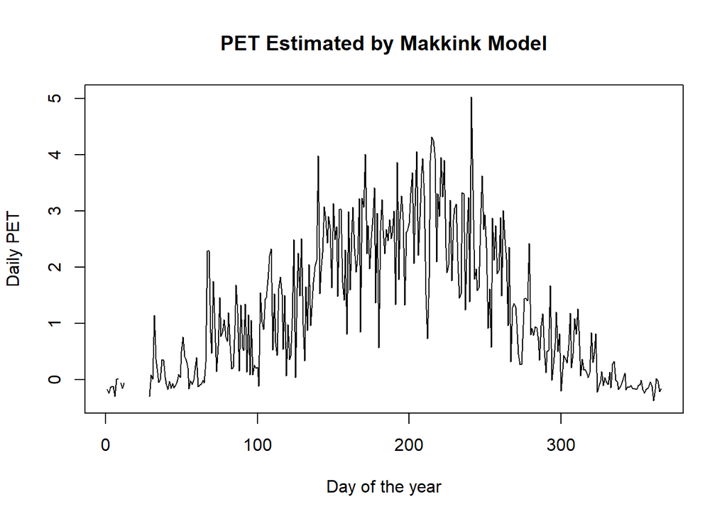

```r
plot(
  dat$Day, PET, type = "l",
  xlab = "Day of the year",
  ylab = "Daily PET",
  main = "PET Estimated by Makkink Model"
)                   # plot PET versus time
```

## References

Makkink, G. F. (1957). Testing the Penman formula by means of lysimeters. Journal of the Institution of Water Engineerrs, 11, 277–288.

Zenone, T., Chen, J., Deal, M. W., Wilske, B., Jasrotia, P., Xu, J., Bhardwaj, A. K., Hamilton, S. K., and Robertson, G. P. (2011). CO2 fluxes of transitional bioenergy crops: Effect of land conversion during the first year of cultivation. Global Change Biology-Bioenergy, 3(5), 401–412.